# CFP parcels with major canopy loss

Houghton & Keweenaw Counties, Michigan

Authors

Randy Swaty

Julia Petersen

Published

October 26, 2026

### Summary

Using Commercial Forest Parcel (CFP) data for 2020 and 2026 from the Michigan Department of Natural Resources alongside the USFS FIA Total Canopy Cover (TCC) dataset across Houghton and Keweenaw counties, I screened for parcels with mean canopy cover change steeper than −20 percentage points between 2020 and 2025.[^1] All of the information below is for that major-loss subset.

Of 2,128 CFP parcels ≥20 acres, **72 parcels (~12,219 acres)** lost more than **20 percent** of mean tree canopy from 2020 to 2025. Almost all kept the state **Forest Industry** owner-type label[^2] — but most **changed legal name**, with the most common change being TRG Threshold → Verdant Timber.

### Key numbers

[output not shown]

### General Parcel Size Distribution

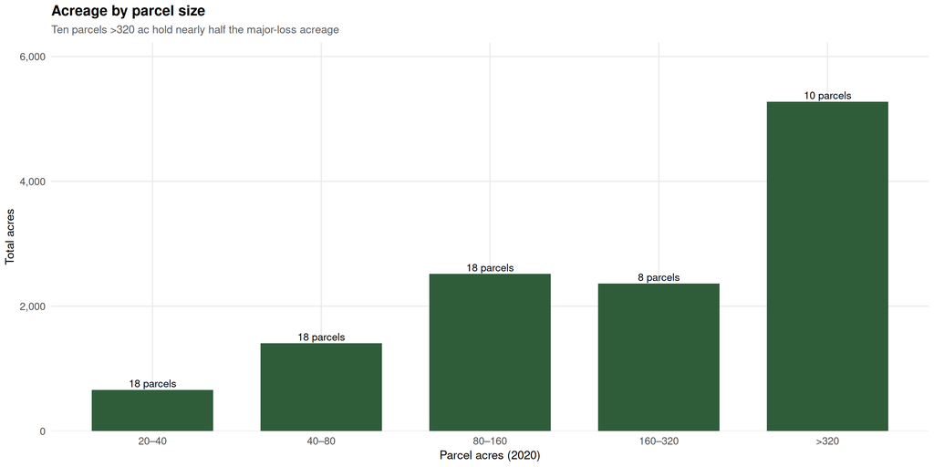

Figure 1: Size of the 72 major-loss parcels.

### Parcel type and owner transitions for parcels with greatest canopy cover change

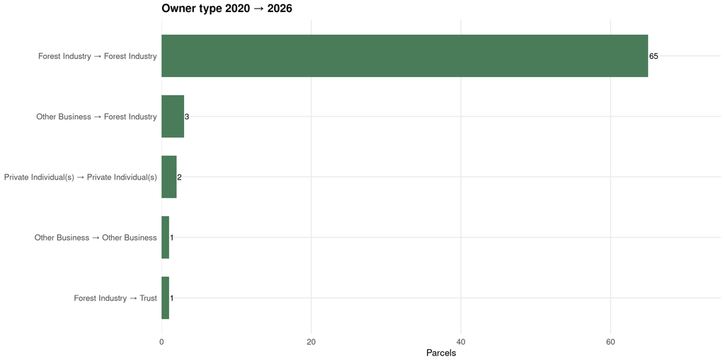

Figure 2: Ownership type continuity among major-loss parcels.

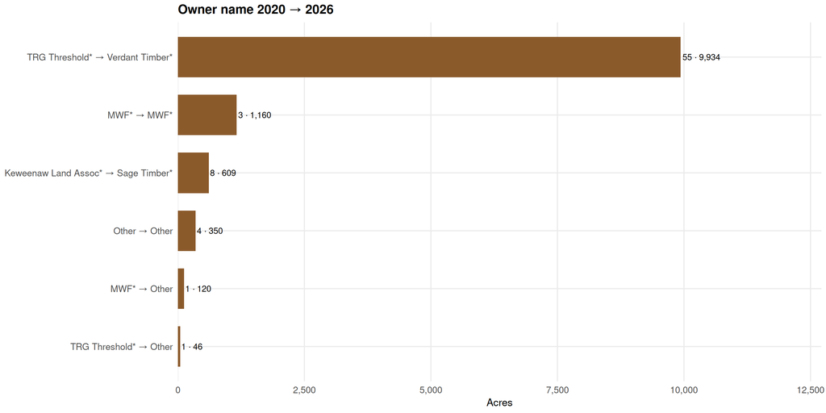

Figure 3: Ownership name continuity among major-loss parcels.

### Canopy cover change

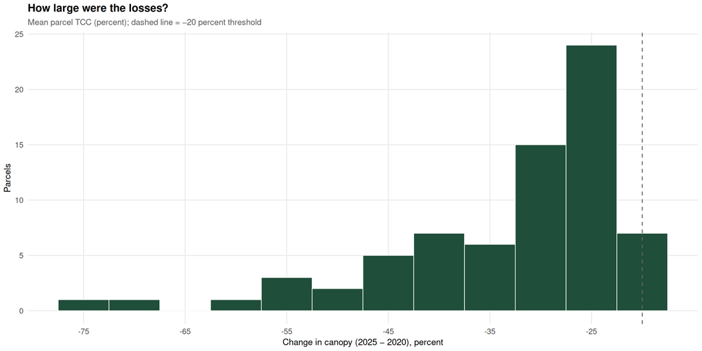

Figure 4: Distribution of canopy change (percent) for major-loss parcels.

### Takeaway

The ~12,219 acres of **major canopy loss** are concentrated on CFP land that kept the **Forest Industry** type label. Continuity of owner *type* masks substantial **legal-name turnover**, especially **TRG Threshold Timber → Verdant Timber** (~55 parcels / ~9,934 ac) and **Keweenaw Land Association → Sage Timber** (8 parcels / ~609 ac). None of these 72 parcels left the CFP between 2020 and 2026.

**Institutional owners vs Forest Industry.** TRG (and Verdant), Lyme, and MWF are the large **institutional** names in this geography; they usually appear under the state’s Forest Industry type. Stars in the name chart (`TRG Threshold*`, `MWF*`, etc.) mark **collapsed name groups** (several legal entities rolled up), not a quality flag. **MWF** is the CFP legal-name token for MWF Ned Lake / MWF V Vulcan entities (Molpus-family stand-in in the sellers/keepers analysis; no literal “Molpus” or “Manulife” strings in HK CFP 2020).

**Heartlands / TNC.** TRG → Nature Conservancy transfers are largely **outside** this major-loss subset (0 of the 72 major-loss parcels; ~0 ac). By contrast, 18 of the TRG → Verdant major-loss parcels lie inside the **American Songbird** footprint, which Verdant sold in 2026 (after the CFP 2026 snapshot, so it still reads as Verdant here). See `docs/cfp_institutional_sellers_keepers.qmd` for the seller vs keeper comparison.

### Methods (short)

- **Unit:** 2020 CFP parcels (`parid`), ranked for all parcels with attribute acres ≥ 20.
- **Canopy:** zonal mean USFS/NLCD TCC on the 30 m grid, **2020 vs 2025** (latest annual TCC; ownership snapshot is 2026).
- **Major loss:** mean ΔTCC < −20 percent (72 of 2,128 ranked parcels); see footnote in Summary.
- **Ownership:** 2020 `owner_type` / `search_nam`; 2026 `OwnerTypeT` / `FullLegalN`, joined on `parid`.
- **Name match:** loose string compare (case, punctuation, LLC/Inc stripped). Source table: `output_csvs/cfp_parcel_tcc_change_by_owner_type.csv` (`scripts/09_cfp_parcel_tcc_change.R`).
- **Related:** institutional sellers vs keepers disturbance rates — `scripts/10_institutional_sellers_vs_keepers.R`.

## Footnotes

[^1]: The −20 pp cut is a **screening threshold** for “major” parcel-mean loss in this memo—not an industry biodiversity standard or a claim that every such change is harvest rather than other disturbance. Edge spill from neighboring heavy-loss parcels can push a parcel’s mean below −20 pp even when interior cover is steadier; parcels adjacent to very high-loss neighbors with smaller mean changes are outside this set.
[^2]: Michigan DNR assigns CFP `owner_type` / `OwnerTypeT` categories (including Forest Industry); it is a program classification, not our institutional-owner roster. See `docs/cfp_institutional_sellers_keepers.qmd` for TRG / Lyme / MWF contrasts.